# Analysis using R

Vivek Vijayaraghavan

4/4/2019

# 1 Introduction

The code portfolio for analysis using R will focus on the machine learning techniques, analysis associated with those techniques, evaluation of the performance and error measures to validate the models and the influence of supervised, unsupervised and semi-supervised learning.

In the sections below, there will be an overview and brief explanation of the concepts. More importantly, along with the core machine learning techniques of classification, regression and clustering, there will be examples on how to run and evaluate the models. Multiple datasets are used deliberately to highlight the various concepts as it breaks the monotony of using the same dataset, but also helping in understanding the structure and context of the datasets and the choice of the machine learning models that are applied on them.

## 1.1 References

The primary reference to the content here is from the datacamp course.

- [Intro to Machine Learning with R](https://campus.datacamp.com/courses/introduction-to-machine-learning-with-r).
- [ROC Curve](https://rpubs.com/H_Zhu/235617)
- [k means clustering](https://uc-r.github.io/kmeans_clustering).

# 2 Machine Learning Overview

The basic concept of machine learning is to build a model that can make predictions about the current data as well as future instances of similar problems. Machine learning is more than simply computing averages or performing some data manipulation. It actually involves making predictions about observations based on previous information. Some machine learning examples are predicting height/weight using linear regression function, recommendation engines, self-driving car decision making analysis etc.

## 2.1 Estimation Functions

A function is some transformation that is applied on the inputs to generate an output. This function can be very specific (formula or relation between input and out is already defined and specified) or estimated (based on the input provided and prior known conditions, we estimate/predict what the output value will be). Note that in case of the estimated function, the direct relation between the input and output may not be define apriori.

## 2.2 Basic Prediction Model

The most basic of the prediction model has three steps. They are:

- Build a linear regression model from a dataset.
- Define the dataframe for the specific data we want to predict (input) and
- Use the predict function to predict the output.

In the example below, we are trying to predict the wage for a 60 year olde worker. The dataset wage (part of ISLR package) contains data about the wage of workers along with their age. We will build a linear regression model and then use the predic function by pass in this model as well as the data from which we want to predict. In the example below, the prediction of the wage for a 60 year old works is approximately USD 124/-. We were able to predict this value

```r
library('ISLR')
data(Wage) #Load the builtin dataset Wage.
head(Wage) # Top 6 rows of the dataset Wage.
```

|  | year | age | maritl | race | education | region | jobclass | health | health_ins | logwage | wage |
| --- | --- | --- | --- | --- | --- | --- | --- | --- | --- | --- | --- |
| 231655 | 2006 | 18 | 1. Never Married | 1. White | 1. < HS Grad | 2. Middle Atlantic | 1. Industrial | 1. <=Good | 2. No | 4.318063 | 75.04315 |
| 86582 | 2004 | 24 | 1. Never Married | 1. White | 4. College Grad | 2. Middle Atlantic | 2. Information | 2. >=Very Good | 2. No | 4.255273 | 70.47602 |
| 161300 | 2003 | 45 | 2. Married | 1. White | 3. Some College | 2. Middle Atlantic | 1. Industrial | 1. <=Good | 1. Yes | 4.875061 | 130.98218 |
| 155159 | 2003 | 43 | 2. Married | 3. Asian | 4. College Grad | 2. Middle Atlantic | 2. Information | 2. >=Very Good | 1. Yes | 5.041393 | 154.68529 |
| 11443 | 2005 | 50 | 4. Divorced | 1. White | 2. HS Grad | 2. Middle Atlantic | 2. Information | 1. <=Good | 1. Yes | 4.318063 | 75.04315 |
| 376662 | 2008 | 54 | 2. Married | 1. White | 4. College Grad | 2. Middle Atlantic | 2. Information | 2. >=Very Good | 1. Yes | 4.845098 | 127.11574 |

```r
# Build a linear regression model that can predict the wage of a worker based on the age.
lm_wage <- lm(wage ~ age, data = Wage)

data_60 <- data.frame(age = 60) #Create a dataframe with data of all workers whose age is 60.

predict(lm_wage, data_60) #Use predict function to determine the wage of a 60 year old worker.
```

```
##        1
## 124.1413
```

## 2.3 Machine Learning Techniques

### 2.3.1 Classification

The goal of the classification problem is to predict if a given observation belongs to a certain category. Some examples of classification problem in machine learning is in medical diagnosis (sick, not sick), animal recognition (cat, horse, dog) etc. The main characterisitics of classifier technique is that the output is qualitative and the types of classes that an input can be classified is known apriori.

### 2.3.2 Regression

The goal of the regression model is to fit a linear function between predictor and response. For example, based on the height and weight relation among a group of people, is it possible to predict the weight of a person, given their height. The linear regression function we are trying to fit is:
$$Height \approx \beta_0 + \beta_1 \ast Weight$$
where $\beta_0$ and $\beta_1$ are known as the model co-efficients (or parameters) and is estimated based on previous input-output values. Some applications of regression models are credit scoring, paying for subcriptions over time and landing a job based on grades and college attended. Th emain characteristic of the regression technique is that the output is quantitative and is calculated from previous knowledge of input-output observations.

### 2.3.3 Clustering

The goal of clustering model is group inputs into clusters of similar values, while the clusters themselvs are dissimialr from each other. Clustering does not require any knowledge of labels. Ther eis no right or worng answers with clustering and can vary based on how the clusters are formed. One of the common examples of clustering is k-means clustering, that groups input data into k clusters based on the similarity measures.

Let us use the iris dataset to help articulate clustering mechanism. First, looking at the dataset, we can see that each observation has an associated species setosa, versicolor and virginica. To highlight the clustering method, we will create a dataframe without the species information. We will be using clusyering to group the observations and then analyze how close (or far) was our clustering function.

```r
data(iris) #Load the builtin dataset iris
head(iris) # Top 6 rows of the dataset iris
```

|  | Sepal.Length | Sepal.Width | Petal.Length | Petal.Width | Species |
| --- | --- | --- | --- | --- | --- |
| 1 | 5.1 | 3.5 | 1.4 | 0.2 | setosa |
| 2 | 4.9 | 3.0 | 1.4 | 0.2 | setosa |
| 3 | 4.7 | 3.2 | 1.3 | 0.2 | setosa |
| 4 | 4.6 | 3.1 | 1.5 | 0.2 | setosa |
| 5 | 5.0 | 3.6 | 1.4 | 0.2 | setosa |
| 6 | 5.4 | 3.9 | 1.7 | 0.4 | setosa |

```r
set.seed(1) # Set random seed. Don't remove this line. This is used to find our frame of reference.

# Chop up iris in my_iris and species
my_iris <- iris[-5]
species <- iris$Species

# Perform k-means clustering on my_iris: kmeans_iris
kmeans_iris <- kmeans(my_iris, 3)

# Compare the actual Species to the clustering using table()
table(kmeans_iris$cluster, species)
```

```
##    species
##     setosa versicolor virginica
##   1     50          0         0
##   2      0          2        36
##   3      0         48        14
```

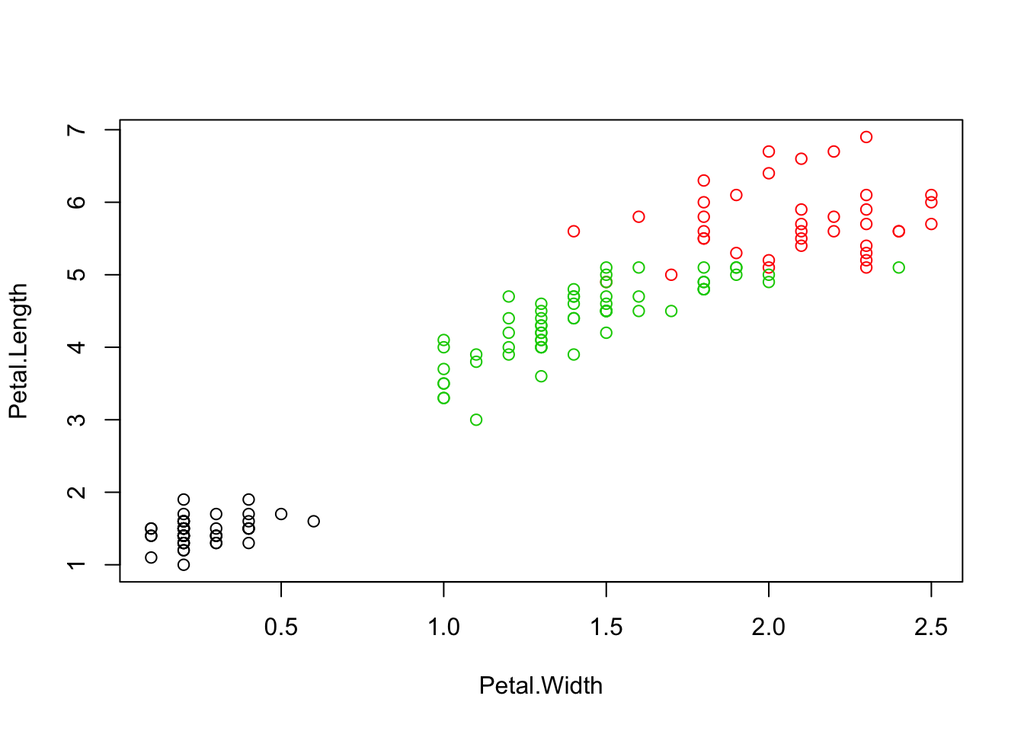

```r
# Plot Petal.Width against Petal.Length, coloring by cluster
plot(Petal.Length ~ Petal.Width, data = my_iris, col = kmeans_iris$cluster)
```

## 2.4 Supervised vs Unsupervised Learning

Supervised learning is to find an estimation function which can be used to assign a class or value to unseen observations, given a set of labeled observations. Classification and Regression techniques fall into this category of supervised learning. Unsupervised learning does ot require labeled observations and will learn from the data to group similar observations. Clustering is a form of unsupervised learning. Semi-Supervised learning can be used where we have lots of unlabeled observations and a few labelled observations. We can then use clustering to group similar observations and then use labels to label the observations. We can then run supervised learning on the labelled observations.

### 2.4.1 Supervised Learning

In thie example below, we will use the iris dataset and use the Species column (label) to do some supervised learning using recursive partitioning.

```r
# Set random seed. Don't remove this line.
set.seed(1)

# Take a look at the iris dataset
str(iris)
```

```
## 'data.frame':    150 obs. of  5 variables:
##  $ Sepal.Length: num  5.1 4.9 4.7 4.6 5 5.4 4.6 5 4.4 4.9 ...
##  $ Sepal.Width : num  3.5 3 3.2 3.1 3.6 3.9 3.4 3.4 2.9 3.1 ...
##  $ Petal.Length: num  1.4 1.4 1.3 1.5 1.4 1.7 1.4 1.5 1.4 1.5 ...
##  $ Petal.Width : num  0.2 0.2 0.2 0.2 0.2 0.4 0.3 0.2 0.2 0.1 ...
##  $ Species     : Factor w/ 3 levels "setosa","versicolor",..: 1 1 1 1 1 1 1 1 1 1 ...
```

```r
summary(iris)
```

```
##   Sepal.Length    Sepal.Width     Petal.Length    Petal.Width
##  Min.   :4.300   Min.   :2.000   Min.   :1.000   Min.   :0.100
##  1st Qu.:5.100   1st Qu.:2.800   1st Qu.:1.600   1st Qu.:0.300
##  Median :5.800   Median :3.000   Median :4.350   Median :1.300
##  Mean   :5.843   Mean   :3.057   Mean   :3.758   Mean   :1.199
##  3rd Qu.:6.400   3rd Qu.:3.300   3rd Qu.:5.100   3rd Qu.:1.800
##  Max.   :7.900   Max.   :4.400   Max.   :6.900   Max.   :2.500
##        Species
##  setosa    :50
##  versicolor:50
##  virginica :50
##
##
##
```

```r
# Load rpart package
library('rpart')

# Build a decision tree model based on Species label...
tree <- rpart(Species ~ Sepal.Length + Sepal.Width + Petal.Length + Petal.Width,
              data = iris, method = "class")

# A dataframe containing unseen observations
unseen <- data.frame(Sepal.Length = c(5.3, 7.2),
                     Sepal.Width = c(2.9, 3.9),
                     Petal.Length = c(1.7, 5.4),
                     Petal.Width = c(0.8, 2.3))

# Predict the label of the unseen observations. Print out the result.
predict(tree, unseen, type = "class")
```

```
##         1         2
##    setosa virginica
## Levels: setosa versicolor virginica
```

### 2.4.2 Unsupervised Learning

```r
# The cars data frame is part of the builtin dataset mtcars

# Set random seed. Don't remove this line.
set.seed(1)

# Explore the cars dataset
str(cars)
```

```
## 'data.frame':    50 obs. of  2 variables:
##  $ speed: num  4 4 7 7 8 9 10 10 10 11 ...
##  $ dist : num  2 10 4 22 16 10 18 26 34 17 ...
```

```r
summary(cars)
```

```
##      speed           dist
##  Min.   : 4.0   Min.   :  2.00
##  1st Qu.:12.0   1st Qu.: 26.00
##  Median :15.0   Median : 36.00
##  Mean   :15.4   Mean   : 42.98
##  3rd Qu.:19.0   3rd Qu.: 56.00
##  Max.   :25.0   Max.   :120.00
```

```r
# Group the dataset into two clusters: km_cars
km_cars <- kmeans(cars, 2)

# Print out the contents of each cluster
print(km_cars)
```

```
## K-means clustering with 2 clusters of sizes 32, 18
##
## Cluster means:
##      speed     dist
## 1 12.84375 27.15625
## 2 19.94444 71.11111
##
## Clustering vector:
##  [1] 1 1 1 1 1 1 1 1 1 1 1 1 1 1 1 1 1 1 1 1 1 2 2 1 1 2 1 1 1 1 2 1 2 2 2
## [36] 1 1 2 1 1 2 2 2 2 2 2 2 2 2 2
##
## Within cluster sum of squares by cluster:
## [1] 5018.438 6052.722
##  (between_SS / total_SS =  67.4 %)
##
## Available components:
##
## [1] "cluster"      "centers"      "totss"        "withinss"
## [5] "tot.withinss" "betweenss"    "size"         "iter"
## [9] "ifault"
```

```r
# Add points to the cluster and color code them for each cluster
plot(cars, col = km_cars$cluster)

# Print out the cluster centroids
print(km_cars$centers)
```

```
##      speed     dist
## 1 12.84375 27.15625
## 2 19.94444 71.11111
```

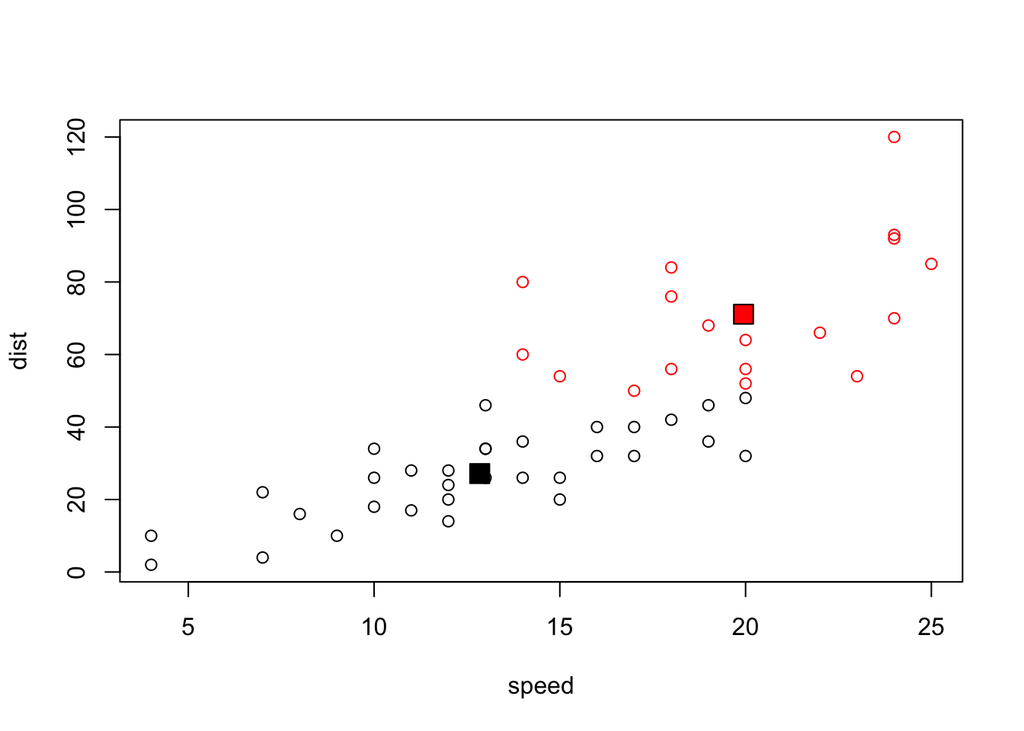

```r
# Add the centroids to the plot
points(km_cars$centers, pch = 22, bg = c(1, 2), cex = 2)
```

## 2.5 Performance and/or Error Measures

How do we figure out if the model is any good. For this we need to understand the context of the tasks being performed. Accuracy, Computation time, Interpretability are all factors affecting the quallity of the model. For the various techniques of machine learning, these measures can vary.

### 2.5.1 Classification Measures using Confusion Matrix

Confusion Matrix is used with Classification technique and contains rows and columns (matrix) of all available labels. Each cell contains teh frequency of the instances (observations) classified in a certain way. Binary Classifiers have a positive (1) and negative (0) values. Consider the rows to be the outcomes of the truth and the columns the outcomes of the predition. This yields a matrix as below:

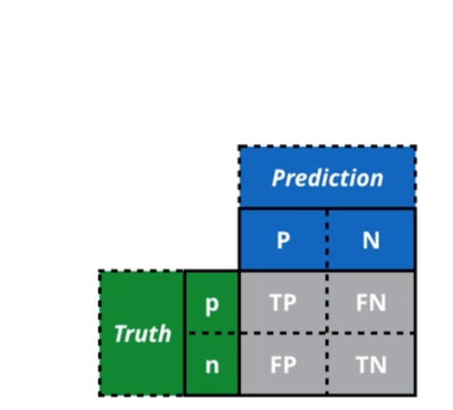

The confusion matrix can be used to calculate ratios such as accuracy, precision and recall. Accuracy is $Total Correct Observations / Total Observations = (TP+TN) / (TP+TN+FP+FN)$, precision is $TP/(TP+FP)$ and recall is $TP / (TP + FN)$. We can use these three measures to be able to better understand the performance of the model.

```r
# The titanic data is part of the titanic package and can be installed.
# This data gave some inconsistent resukts, hence getting the titanic data from kaggle site.
# install.packages('titanic')
# library(titanic)

# Import titianic traing and test data from csv file...
titanic_train <- read.csv("titanic_train.csv", header=TRUE)
titanic_test <- read.csv("titanic_test.csv", header=TRUE)
# Cannot merge the two datasets as the columns (features) do not match
# The test dataset does not have the Survived attribute calculated.
# titanic <- rbind(titanic_train, titanic_test)

# Set random seed. Don't remove this line.
set.seed(101)

# Have a look at the structure of titanic
str(titanic_train)
```

```
## 'data.frame':    891 obs. of  12 variables:
##  $ PassengerId: int  1 2 3 4 5 6 7 8 9 10 ...
##  $ Survived   : int  0 1 1 1 0 0 0 0 1 1 ...
##  $ Pclass     : int  3 1 3 1 3 3 1 3 3 2 ...
##  $ Name       : Factor w/ 891 levels "Abbing, Mr. Anthony",..: 109 191 358 277 16 559 520 629 417 581 ...
##  $ Sex        : Factor w/ 2 levels "female","male": 2 1 1 1 2 2 2 2 1 1 ...
##  $ Age        : num  22 38 26 35 35 NA 54 2 27 14 ...
##  $ SibSp      : int  1 1 0 1 0 0 0 3 0 1 ...
##  $ Parch      : int  0 0 0 0 0 0 0 1 2 0 ...
##  $ Ticket     : Factor w/ 681 levels "110152","110413",..: 524 597 670 50 473 276 86 396 345 133 ...
##  $ Fare       : num  7.25 71.28 7.92 53.1 8.05 ...
##  $ Cabin      : Factor w/ 148 levels "","A10","A14",..: 1 83 1 57 1 1 131 1 1 1 ...
##  $ Embarked   : Factor w/ 4 levels "","C","Q","S": 4 2 4 4 4 3 4 4 4 2 ...
```

```r
# A decision tree classification model is built on the data
tree <- rpart(Survived ~ ., data = titanic_train, method = "class")

# Use the predict() method to make predictions, assign to pred
pred <- predict(tree, titanic_train, type = "class")

# Use the table() method to make the confusion matrix
conf <- table(titanic_train$Survived, pred)

# Assign TP, FN, FP and TN using conf
TP <- conf[1, 1] # this will be 549
FN <- conf[1, 2] # this will be 0
FP <- conf[2, 1] # this will be 0
TN <- conf[2, 2] # this will be 342

# Calculate and print the accuracy: acc
acc = (TP + TN) / (TP + FN + FP + TN)
print(acc)
```

```
## [1] 1
```

```r
# Calculate and print out the precision: prec
prec = (TP ) / (TP + FP)
print(prec)
```

```
## [1] 1
```

```r
# Calculate and print out the recall: rec
rec = (TP ) / (TP + FN)
print(rec)
```

```
## [1] 1
```

### 2.5.3 Clustering measures

Clustering measures are different from the above two as there is no apriori labels available. The performance mesures consists of two elements. Similarity within a cluster (which should be high) and similarity between clusters (which should be low). For Within cluster similarity, we can measure within sum of squares (wss) and the diameter size. The smaller the wss and diameter the more similar are the elements within the cluster. For between cluster similarity, we can use the between sum of squares and the intercluster distance. The higher these values, the more dissimilar are the clusters.

Another measure in clustering is the Dunn’s index. This index can be represented as $minimal intercluster distance / maximal diameter$. There are multiple measures to quantitatively describe the models. The most important factor is to think critically and understand the model being applied and then use the approriate measure.

An example of getting and validating performance measures for clustering is given below:

```r
# The seeds data is part of the UCIMLR repository. However, loading the data using R gives the warning
# "package ‘seeds’ is not available (for R version 3.5.1)"

# Hence loading the seeds data from txt file.
seeds_raw <- read.table('seeds_dataset.txt', sep = '\t',header = FALSE)
seeds <- seeds_raw[-8]
colnames( seeds ) <- c('area', 'perimeter', 'compactness', 'length', 'width', 'asymmetry', 'groove_length')

# Set random seed. Don't remove this line.
set.seed(1)

# Explore the structure of the dataset
str(seeds)
```

```
## 'data.frame':    210 obs. of  7 variables:
##  $ area         : num  15.3 14.9 14.3 13.8 16.1 ...
##  $ perimeter    : num  14.8 14.6 14.1 13.9 15 ...
##  $ compactness  : num  0.871 0.881 0.905 0.895 0.903 ...
##  $ length       : num  5.76 5.55 5.29 5.32 5.66 ...
##  $ width        : num  3.31 3.33 3.34 3.38 3.56 ...
##  $ asymmetry    : num  2.22 1.02 2.7 2.26 1.35 ...
##  $ groove_length: num  5.22 4.96 4.83 4.8 5.17 ...
```

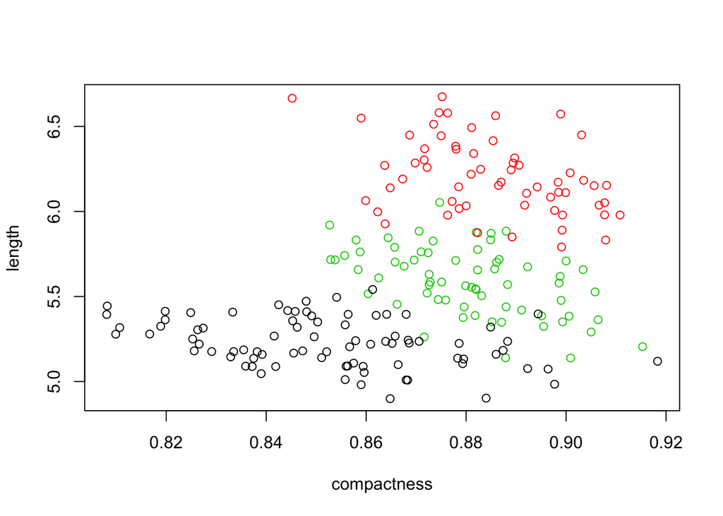

```r
# Group the seeds in three clusters
km_seeds <- kmeans(seeds, 3)

# Color the points in the plot based on the clusters
plot(length ~ compactness, data = seeds, col = km_seeds$cluster)
```

```r
# legend(.82, 6.5, legend=unique(km_seeds$cluster),col=unique(as.numeric(km_seeds$cluster)),pch=19)

# Print out the ratio of the WSS to the BSS
km_seeds$tot.withinss / km_seeds$betweenss
```

```
## [1] 0.2762846
```

### 2.5.4 Datasets - Training and Test Data

```r
# Using iris dataset that was already loaded as part of the previous section in this file.
str(titanic_train)
```

```
## 'data.frame':    891 obs. of  12 variables:
##  $ PassengerId: int  1 2 3 4 5 6 7 8 9 10 ...
##  $ Survived   : int  0 1 1 1 0 0 0 0 1 1 ...
##  $ Pclass     : int  3 1 3 1 3 3 1 3 3 2 ...
##  $ Name       : Factor w/ 891 levels "Abbing, Mr. Anthony",..: 109 191 358 277 16 559 520 629 417 581 ...
##  $ Sex        : Factor w/ 2 levels "female","male": 2 1 1 1 2 2 2 2 1 1 ...
##  $ Age        : num  22 38 26 35 35 NA 54 2 27 14 ...
##  $ SibSp      : int  1 1 0 1 0 0 0 3 0 1 ...
##  $ Parch      : int  0 0 0 0 0 0 0 1 2 0 ...
##  $ Ticket     : Factor w/ 681 levels "110152","110413",..: 524 597 670 50 473 276 86 396 345 133 ...
##  $ Fare       : num  7.25 71.28 7.92 53.1 8.05 ...
##  $ Cabin      : Factor w/ 148 levels "","A10","A14",..: 1 83 1 57 1 1 131 1 1 1 ...
##  $ Embarked   : Factor w/ 4 levels "","C","Q","S": 4 2 4 4 4 3 4 4 4 2 ...
```

```r
# Set random seed. Don't remove this line.
set.seed(1)

# Shuffle the dataset, call the result shuffled
n <- nrow(titanic_train)
shuffled <- titanic_train[sample(n),]

# Split the data in train and test
train_indicies <- 1:round(0.7 * n)
train <- shuffled[train_indicies, ]
test_indices <- (round(0.7 * n) + 1):n
test <- shuffled[test_indices, ]


# Print the structure of train and test
str(train)
```

```
## 'data.frame':    624 obs. of  12 variables:
##  $ PassengerId: int  237 332 510 807 179 796 837 585 556 55 ...
##  $ Survived   : int  0 0 1 0 0 0 0 0 0 0 ...
##  $ Pclass     : int  2 1 3 1 2 2 3 3 1 1 ...
##  $ Name       : Factor w/ 891 levels "Abbing, Mr. Anthony",..: 375 642 460 35 325 626 643 645 881 625 ...
##  $ Sex        : Factor w/ 2 levels "female","male": 2 2 2 2 2 2 2 2 2 2 ...
##  $ Age        : num  44 45.5 26 39 30 39 21 NA 62 65 ...
##  $ SibSp      : int  1 0 0 0 0 0 0 0 0 0 ...
##  $ Parch      : int  0 0 0 0 0 0 0 0 0 1 ...
##  $ Ticket     : Factor w/ 681 levels "110152","110413",..: 199 21 81 13 170 224 269 292 53 30 ...
##  $ Fare       : num  26 28.5 56.5 0 13 ...
##  $ Cabin      : Factor w/ 148 levels "","A10","A14",..: 1 58 1 13 1 1 1 1 1 25 ...
##  $ Embarked   : Factor w/ 4 levels "","C","Q","S": 4 4 4 4 4 4 4 2 4 2 ...
```

```r
str(test)
```

```
## 'data.frame':    267 obs. of  12 variables:
##  $ PassengerId: int  561 316 468 786 306 677 559 790 82 789 ...
##  $ Survived   : int  0 1 0 0 1 0 1 0 1 1 ...
##  $ Pclass     : int  3 3 1 3 1 3 1 1 3 3 ...
##  $ Name       : Factor w/ 891 levels "Abbing, Mr. Anthony",..: 563 595 771 335 17 735 805 315 742 212 ...
##  $ Sex        : Factor w/ 2 levels "female","male": 2 1 2 2 2 2 1 2 2 2 ...
##  $ Age        : num  NA 26 56 25 0.92 24.5 39 46 29 1 ...
##  $ SibSp      : int  0 0 0 0 1 0 1 0 0 1 ...
##  $ Parch      : int  0 0 0 0 2 0 1 0 0 2 ...
##  $ Ticket     : Factor w/ 681 levels "110152","110413",..: 472 344 45 475 38 295 2 593 312 549 ...
##  $ Fare       : num  7.75 7.85 26.55 7.25 151.55 ...
##  $ Cabin      : Factor w/ 148 levels "","A10","A14",..: 1 1 1 1 64 1 136 46 1 1 ...
##  $ Embarked   : Factor w/ 4 levels "","C","Q","S": 3 4 4 4 4 4 4 2 4 4 ...
```

Now that we have shuffled and split the dataset, we can then use these datasets to train our model and test its predictive power.

```r
# Fill in the model that has been learned.
tree <- rpart(Survived ~ ., train, method = "class")

# Need to make sure that the levels in test and train datasets are the same.
# Cannot have new levels show up inthe test dataset that was not there in train dataset.
id <- which(!(test$Survived %in% levels(train$Survived)))
test$Survived[id] <- NA
#predict(model,newdata=foo.new)
# Predict the outcome on the test set with tree: pred
pred <- predict(tree, train, type = "class")

# Calculate the confusion matrix: conf
conf <- table(train$Survived, pred)

# Print this confusion matrix
print(conf)
```

```
##    pred
##       0   1
##   0 385   0
##   1   0 239
```

Taking it a step further to perform a 6 fold cross validation and with each fold perform an accuracy test. In the examples below, the mean accuracy of classification for a 6 fold cross validation is 78%.

```r
# Initialize the accs vector
accs <- rep(0,6)

for (i in 1:6) {
  # These indices indicate the interval of the test set
  indices <- (((i-1) * round((1/6)*nrow(shuffled))) + 1):((i*round((1/6) * nrow(shuffled))))

  # Exclude them from the train set
  train <- shuffled[-indices,]

  # Include them in the test set
  test <- shuffled[indices,]

  # A model is learned using each training set
  tree <- rpart(Survived ~ ., train, method = "class")

  # Make a prediction on the test set using tree
  pred <- predict(tree, test, type = "class")


  # Assign the confusion matrix to conf
  conf <- table(test$Survived, pred)


  # Assign the accuracy of this model to the ith index in accs
  accs[i] <- sum(diag(conf))/sum(conf)
}

# Print out the mean of accs
print(mean(accs))
```

```
## [1] 0.7815315
```

## 2.6 Classification Deep Dive

Choosing the best feature set to use for spliting can be complex to identify the splitting criteria to choose. One option for identifying splitting criteria can be information gain (entropy) - the information gained from a split, based on the featureset. Nicely divided classes have high entropy and classes scrambled all over the tree have low entropy.

Pruning the decision tree can result in higher bias, but will reduce the chance to overfit. The art is to find the best way to find the stopping criteria. If we keep pruning the tree, we get to a point where we start losing information that affects the accuracy of classifications.

The example below uses the carseats dataset to generate a classification tree, prune the tree and analyze the accuracy of the tree before and after pruning.

```r
# load the Carseats dataframe from the ISLR package
library(ISLR)
data(package="ISLR")
carseats<-Carseats
require(tree)
names(carseats)
```

```
##  [1] "Sales"       "CompPrice"   "Income"      "Advertising" "Population"
##  [6] "Price"       "ShelveLoc"   "Age"         "Education"   "Urban"
## [11] "US"
```

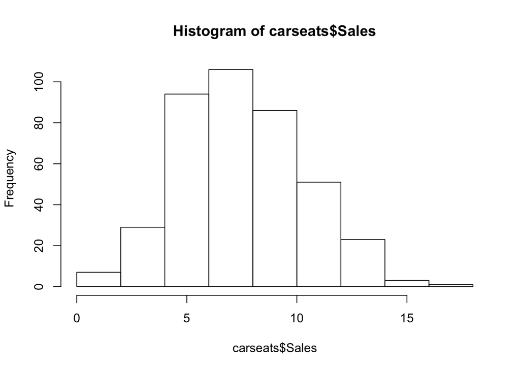

```r
hist(carseats$Sales)
```

The Carseats dataset is a dataframe with 400 observations on the following 11 variables:

- Sales: unit sales in thousands
- CompPrice: price charged by competitor at each location
- Income: community income level in 1000s of dollars
- Advertising: local ad budget at each location in 1000s of dollars
- Population: regional pop in thousands
- Price: price for car seats at each site
- ShelveLoc: Bad, Good or Medium indicates quality of shelving location
- Age: age level of the population
- Education: ed level at location
- Urban: Yes/No
- US: Yes/No

Converting the quantitative variable sales into a binary variable, so we can use the variable for decision in a binary tree classifier. If the sales is greater than 8, we will convert the sales to high and for all else it is low.

```r
High = ifelse(carseats$Sales<=8, "No", "Yes")
carseats = data.frame(carseats, High)

# fill a model using decision trees
tree.carseats = tree(High~.-Sales, data=carseats)
summary(tree.carseats)
```

```
##
## Classification tree:
## tree(formula = High ~ . - Sales, data = carseats)
## Variables actually used in tree construction:
## [1] "ShelveLoc"   "Price"       "Income"      "CompPrice"   "Population"
## [6] "Advertising" "Age"         "US"
## Number of terminal nodes:  27
## Residual mean deviance:  0.4575 = 170.7 / 373
## Misclassification error rate: 0.09 = 36 / 400
```

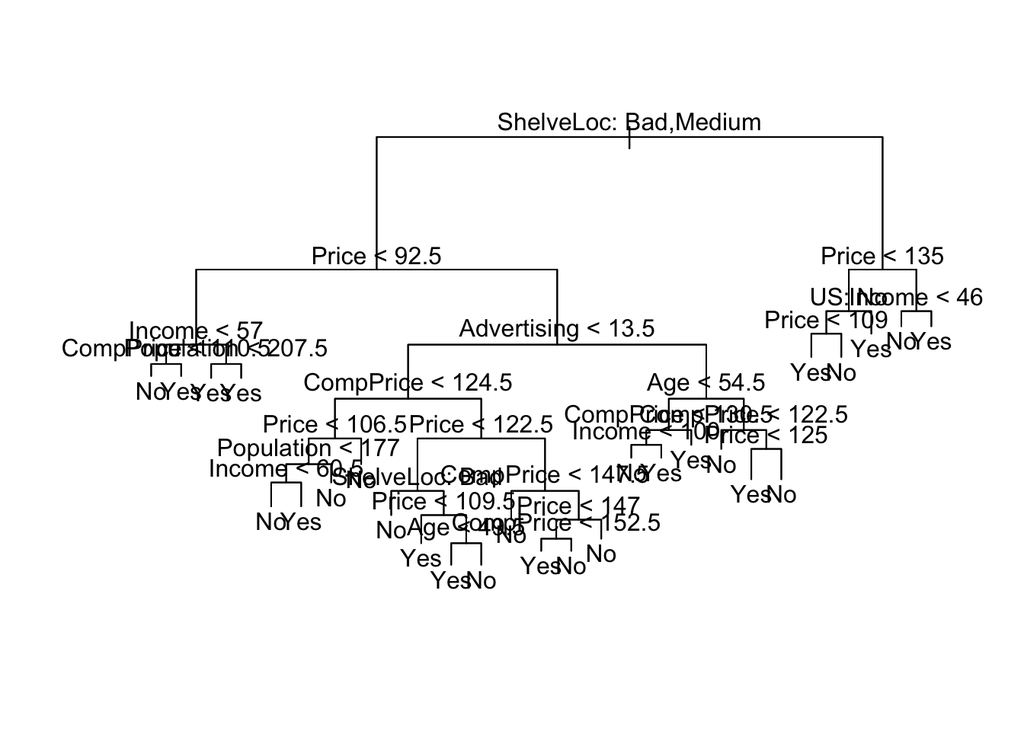

```r
# Visualize the tree using plot
plot(tree.carseats)
text(tree.carseats, pretty = 0)
```

It’s time to prune the tree down. Let’s create a training set and a test by splitting the carseats dataframe into 250 training and 150 test samples.

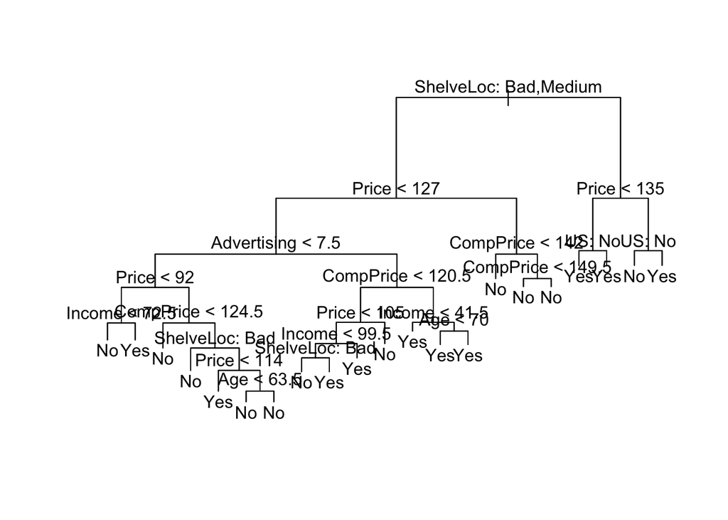

```r
# set a seed to make the results reproducible
set.seed(101)

# Create a training set of 250 observations from thetotal of 400
strain=sample(1:nrow(carseats), 250)

# Create a decision tree from the training dataset
tree.carseats = tree(High~.-Sales, carseats, subset=strain)

# Plot the tree
plot(tree.carseats)
text(tree.carseats, pretty=0)
```

The plot looks a bit different because of the slightly different dataset. Nevertheless, the complexity of the tree looks roughly the same. Now you’re going to take this tree and predict it on the test set, using the predict method for trees. Here you’ll want to actually predict the class labels. Then you can evalute the error by using a misclassification table.

```r
tree.pred = predict(tree.carseats, carseats[-strain,], type="class")
with(carseats[-strain,], table(tree.pred, High))
```

```
##          High
## tree.pred No Yes
##       No  72  16
##       Yes 19  43
```

On the diagonals are the correct classifications, while off the diagonals are the incorrect ones. You only want to recored the correct ones. To do that, you can take the sum of the 2 diagonals divided by the total (150 test observations).

When growing a big bushy tree, it could have too much variance. Thus, let’s use cross-validation to prune the tree optimally. Using cv.tree, you’ll use the misclassification error as the basis for doing the pruning.

Printing out the results shows the details of the path of the cross-validation. You can see the sizes of the trees as they were pruned back, the deviances as the pruning proceeded, as well as the cost complexity parameter used in the process.

Let’s plot this out: Looking at the plot, you see a downward spiral part because of the misclassification error on 250 cross-validated points. So let’s pick a value in the downward steps (12). Then, let’s prune the tree to a size of 12 to identify that tree. Finally, let’s plot and annotate that tree to see the outcome.

```r
cv.carseats = cv.tree(tree.carseats, FUN = prune.misclass)
cv.carseats
```

```
## $size
## [1] 21 15 12  9  7  6  5  2  1
##
## $dev
## [1]  66  66  67  69  72  75  74  72 105
##
## $k
## [1]      -Inf  0.000000  1.000000  1.666667  2.500000  5.000000  6.000000
## [8]  6.666667 34.000000
##
## $method
## [1] "misclass"
##
## attr(,"class")
## [1] "prune"         "tree.sequence"
```

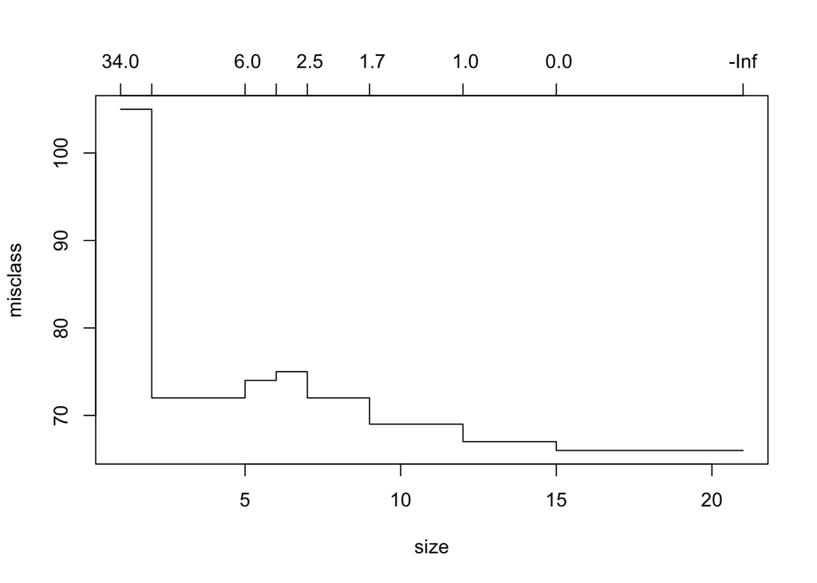

```r
plot(cv.carseats)
```

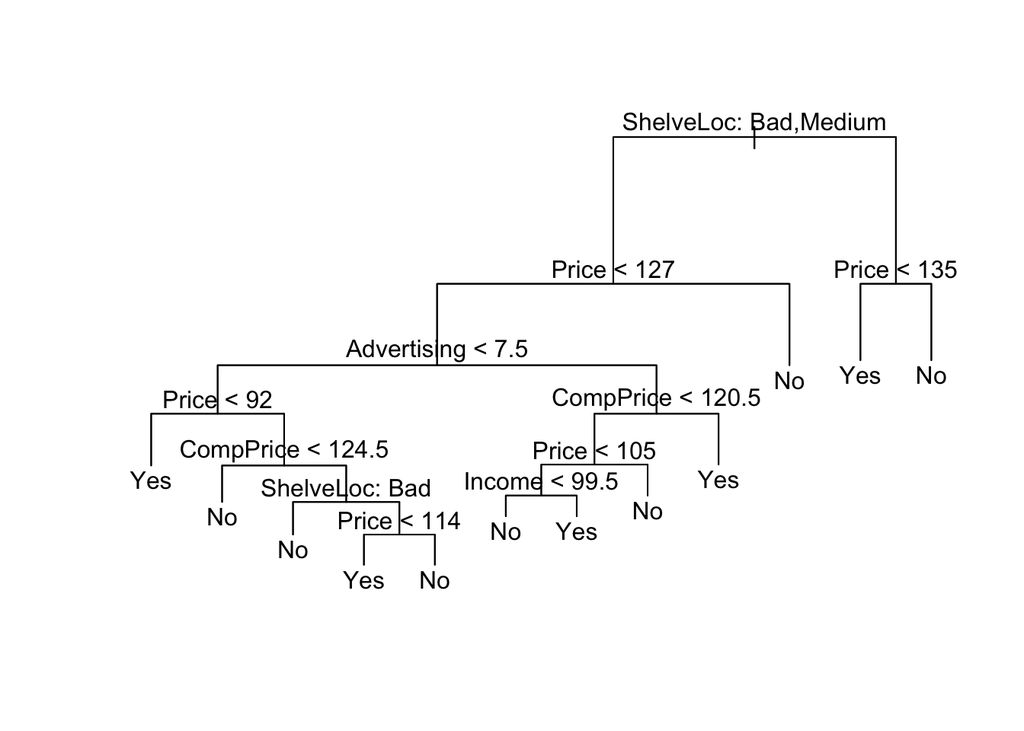

```r
prune.carseats = prune.misclass(tree.carseats, best = 12)
plot(prune.carseats)
text(prune.carseats, pretty=0)
```

It’s a bit shallower than previous trees, and you can actually read the labels. Let’s evaluate it on the test dataset again.

```r
tree.pred = predict(prune.carseats, carseats[-strain,], type="class")
with(carseats[-strain,], table(tree.pred, High))
```

```
##          High
## tree.pred No Yes
##       No  74  20
##       Yes 17  39
```

Seems like the correct classifications dropped a little bit. It has done about the same as your original tree, so pruning did not hurt much with respect to misclassification errors, and gave a simpler tree.

### 2.6.1 K-Nearest Neighbors

This is an instance based learning method. Unlike decision trees there is no clear model, but rather than find nearest neighbor and classify them accordingly. When asked to classify an unseen observation, then the algorithm looks for closest observations and then classify. The distance can be calulated using multiple methods such as standard eucledian distance, manhattan distance etc.

Scaling problem is the fact that calculation of the distance is affected when we scale the features. In the example below, we will use the titanci dataset to normalize the features and then apply the knn algorith for 5 nearest neighbors once and then run the same knn algorithm multiple times, with each time the k is increased to identify the one that gives the optimal accuracy.

```r
# Copy train and test to knn_train and knn_test
knn_train <- na.omit(subset(train, select = c(2, 3, 6)))
knn_test <- na.omit(subset(test, select = c(2, 3, 6)))

# Store the Survived column of train and test in train_labels and test_labels
train_labels <- knn_train$Survived
test_labels <- knn_test$Survived

# Drop Survived column for knn_train and knn_test
knn_train$Survived <- NULL
knn_test$Survived <- NULL

# Normalize Pclass
min_class <- min(knn_train$Pclass)
max_class <- max(knn_train$Pclass)
knn_train$Pclass <- (knn_train$Pclass - min_class) / (max_class - min_class)
knn_test$Pclass <- (knn_test$Pclass - min_class) / (max_class - min_class)

# Normalize Age
min_age <- min(knn_train$Age)
max_age <- max(knn_train$Age)
knn_train$Age <- (knn_train$Age - min_age) / (max_age - min_age)
knn_test$Age <- (knn_test$Age - min_age) / (max_age - min_age)


# Set random seed. Don't remove this line.
set.seed(10)

# Load the class package
library("class")

# make predictions using knn algorithm:
pred <- knn(train = knn_train, test = knn_test, cl = train_labels, k = 5)

# Construct the confusion matrix: conf
conf <- table(test_labels, pred)

# Print out the confusion matrix
print(conf)
```

```
##            pred
## test_labels  0  1
##           0 57 11
##           1 24 24
```

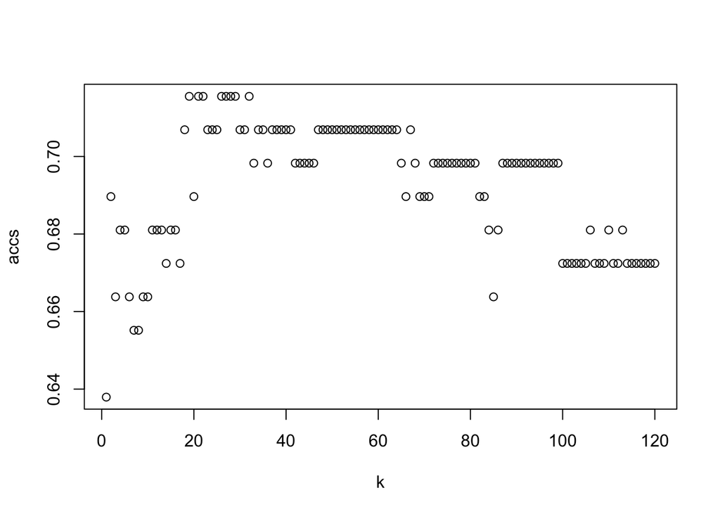

```r
# define range and accs for iterating through the knn algorithm for different values of k
range <- 1:round(0.2 * nrow(knn_train))
accs <- rep(0, length(range))

for (k in range) {

  # make predictions using knn: pred
  pred <- knn(knn_train, knn_test, train_labels, k = k)

  # construct the confusion matrix: conf
  conf <- table(test_labels, pred)

  # calculate the accuracy and store it in accs[k]
  accs[k] <- sum(diag(conf))/sum(conf)
  # print(accs[k])
}

# Plot the accuracies. Title of x-axis is "k".
plot(range, accs, xlab = "k")
```

```r
# Calculate the best k
print(which.max(accs))
```

```
## [1] 19
```

### 2.6.2 ROC Curve

ROC is a very powerful performance measure for binary classifiers. ROC curve stands for Receiver Operator Characteristic curve. There are two ratios that are importatnt in calculating the ROC curve. They are: - True Positive Rate (TPR) and is the same as recall -> TP / (TP + FN) - False Positive Rate (FPR) -> FP / ( FP + TN)

ROC curve is a graph of TPR (Vertical axis) and FPR (Horizontal axis). Inpertreting the ROC curve is to find if th eclassifier can get as close to the upper left corner of the plot. The closer it is to the upper left corner, the better is the classifier output. The upper left is where the TPR is 1 and FPR is 0. AUC (Area under the curve) will be large as we get to the upper left corner of the plot.

So, how doe we create a ROC curve. The example below illustrates it. [Reference](https://rpubs.com/H_Zhu/235617)

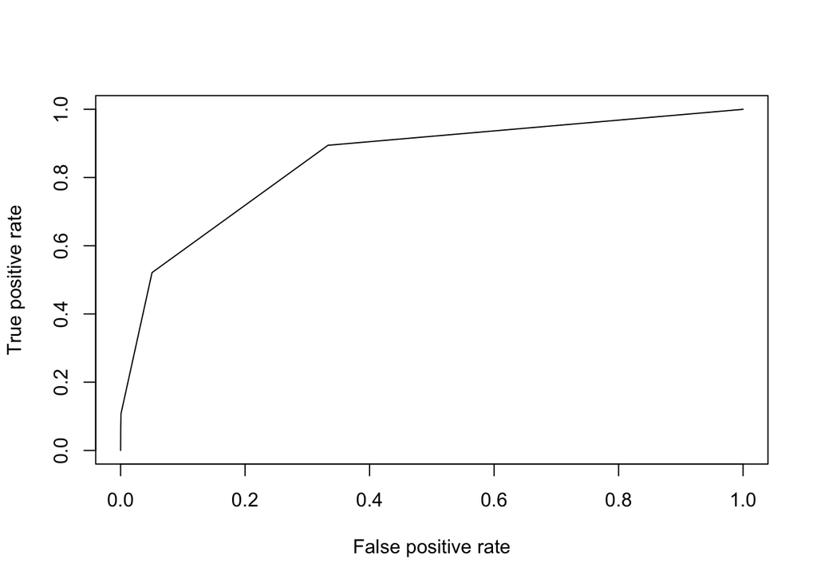

```r
# Set the input data
library(ggplot2)
library(plyr)
library(ROCR)
adult <- read.table('https://archive.ics.uci.edu/ml/machine-learning-databases/adult/adult.data',
                    sep = ',', fill = F, strip.white = T)
colnames(adult) <- c('age', 'workclass', 'fnlwgt', 'educatoin',
                     'educatoin_num', 'marital_status', 'occupation', 'relationship', 'race', 'sex',
                     'capital_gain', 'capital_loss', 'hours_per_week', 'native_country', 'income')


# Create training and testing sets..
sz <- round(.8 * dim(adult)[1])  # training set size
training_set <- adult[1:sz,]
testing_set <- adult[-(1:sz),]


# Set the seed, calculate the tree and identify the probabilities.
set.seed(1)
tree <- rpart(income ~ ., training_set, method = "class")
probs <- predict(tree, testing_set, type = "prob")[,2]

# Make a prediction object: pred
pred <- prediction(probs, testing_set$income)

# Make a performance object: perf
perf <- performance(pred, "tpr", "fpr")
perf1 <- performance(pred, "auc")

# Plot this curve
plot(perf)
```

```r
# Print out the AUC
print(perf1@y.values[[1]])
```

```
## [1] 0.8474472
```

### 2.6.3 Comparing the methods using ROC curve

[figure not shown]

```r
# Set the seed, calculate the tree and identify the probabilities.
set.seed(1)
tree <- rpart(income ~ ., training_set, method = "class")
probs_t <- predict(tree, testing_set, type = "class")
probs_k <- predict(tree, testing_set, type = "prob")[,2]

# Make a prediction object: pred
pred_t <- prediction(as.numeric(probs_t), as.numeric(testing_set$income))
pred_k <- prediction(probs_k, testing_set$income)

# Make a performance object: perf
perf_t <- performance(pred_t, "tpr", "fpr")
perf_k <- performance(pred_k, "tpr", "fpr")

# Plot these curves
plot(perf_t, col="red", ann=FALSE, las=2)
par(new=TRUE)
plot(perf_k, ann=FALSE, axes=FALSE,col='blue')
legend(0.7, 0.2, legend=c("Decision Tree", "KNN"),
       col=c("red", "blue"), lty=1:1, cex=0.8,
       title="Line types", text.font=4, bg='lightblue')
```

## 2.7 Regression Deep Dive

Regression technique is another form for supervised learning. Unlike the classifiers, with regression, we are trying to perdict a specific value instead of a class that the observation fits. In the next couple of sections we will look a little deeper in the various types and concepts of regression.

### 2.7.1 Linear Regression

Simple linear regression model is focussed on a single predictor to model a response and the relation between the predictor and response is approximately linear. Most often than not, a scatterplot is the best mechanism to figure out the plausibility of the linear relationship. In this case, we are trying to fit a line that follows the formal defintion of $Y = \beta_0 + \beta_1 X + \varepsilon$, where X is the predictor and Y is the response. $\beta_0$ is the slope, $\btea_1$ is the slope and $\varepsilon$ is the residual error.

To estimate the co-efficients, we can use the lm() function in R. The example below is a code snippet to highlight on how we go about estimating the co-efficients and draw the regression line.

```r
# New value for which we will predict the estimated value
sepal_width_new = list()
sepal_width_new$Sepal.Width = 5.0

# The iris dataset contains relationship between sepal length and width.
# describe the linear relationship between the two variables: lm_sepal
lm_sepal <- lm(Sepal.Length ~ Sepal.Width, data = iris)

# Print the coefficients of lm_sepal
coefficients(lm_sepal)
```

```
## (Intercept) Sepal.Width
##   6.5262226  -0.2233611
```

```r
# Predict and print the sepal length of the new observation
predict(lm_sepal, sepal_width_new)
```

```
##        1
## 5.409417
```

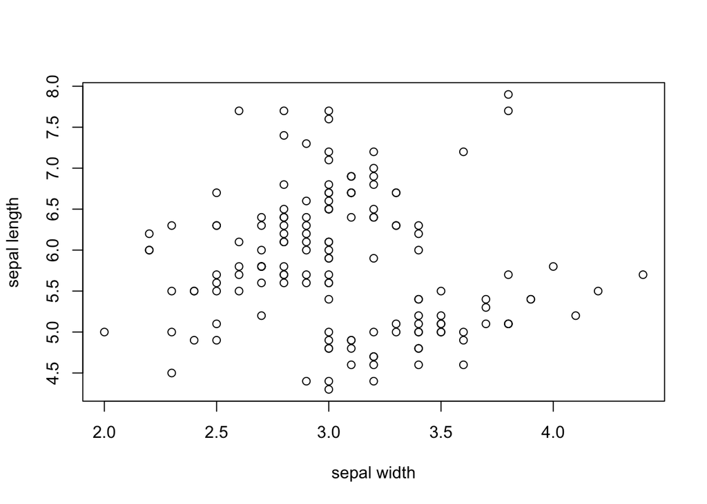

```r
# Build model and make plot
lm_sepal <- lm(Sepal.Width ~ Sepal.Length, data = iris)
plot(iris$Sepal.Width, iris$Sepal.Length, xlab = "sepal width", ylab = "sepal length")
abline(lm_sepal$coefficients, col = "red")
```

```r
# Apply predict() to lm_kang: nose_length_est
sepal_length_est <- predict(lm_sepal, iris)

# Calculate difference between the predicted and the true values: res
res <- iris$Sepal.Width - sepal_length_est

# Calculate RMSE, assign it to rmse and print it
rmse <- sqrt(mean(res^2))
print(rmse)
```

```
## [1] 0.4313982
```

```r
# kang_nose, lm_kang and res are already loaded in your workspace

# Calculate the residual sum of squares: ss_res
ss_res <- sum(res^2)

# Determine the total sum of squares: ss_tot
ss_tot <- sum((iris$Sepal.Width - mean(iris$Sepal.Width))^2)

# Calculate R-squared and assign it to r_sq. Also print it.
r_sq <- (1 - (ss_res/ss_tot))
print(r_sq)
```

```
## [1] 0.01382265
```

```r
# Apply summary() to lm_kang
summary(lm_sepal)
```

```
##
## Call:
## lm(formula = Sepal.Width ~ Sepal.Length, data = iris)
##
## Residuals:
##     Min      1Q  Median      3Q     Max
## -1.1095 -0.2454 -0.0167  0.2763  1.3338
##
## Coefficients:
##              Estimate Std. Error t value Pr(>|t|)
## (Intercept)   3.41895    0.25356   13.48   <2e-16 ***
## Sepal.Length -0.06188    0.04297   -1.44    0.152
## ---
## Signif. codes:  0 '***' 0.001 '**' 0.01 '*' 0.05 '.' 0.1 ' ' 1
##
## Residual standard error: 0.4343 on 148 degrees of freedom
## Multiple R-squared:  0.01382,    Adjusted R-squared:  0.007159
## F-statistic: 2.074 on 1 and 148 DF,  p-value: 0.1519
```

### 2.7.2 Multi-Variable Linear Regression

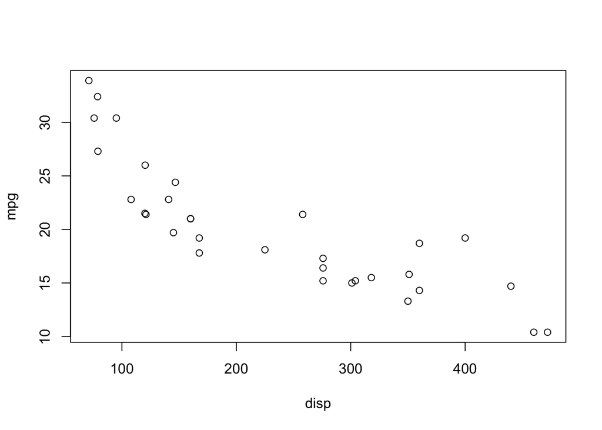

```r
data(mtcars) #load mtcars data

# Create scatter plots: Linearity plausible?
plot(mpg ~ disp, mtcars)
```

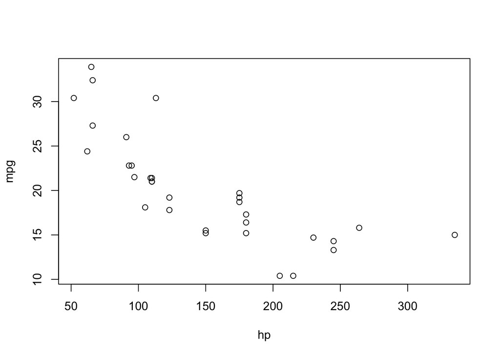

```r
plot(mpg ~ hp, mtcars)
```

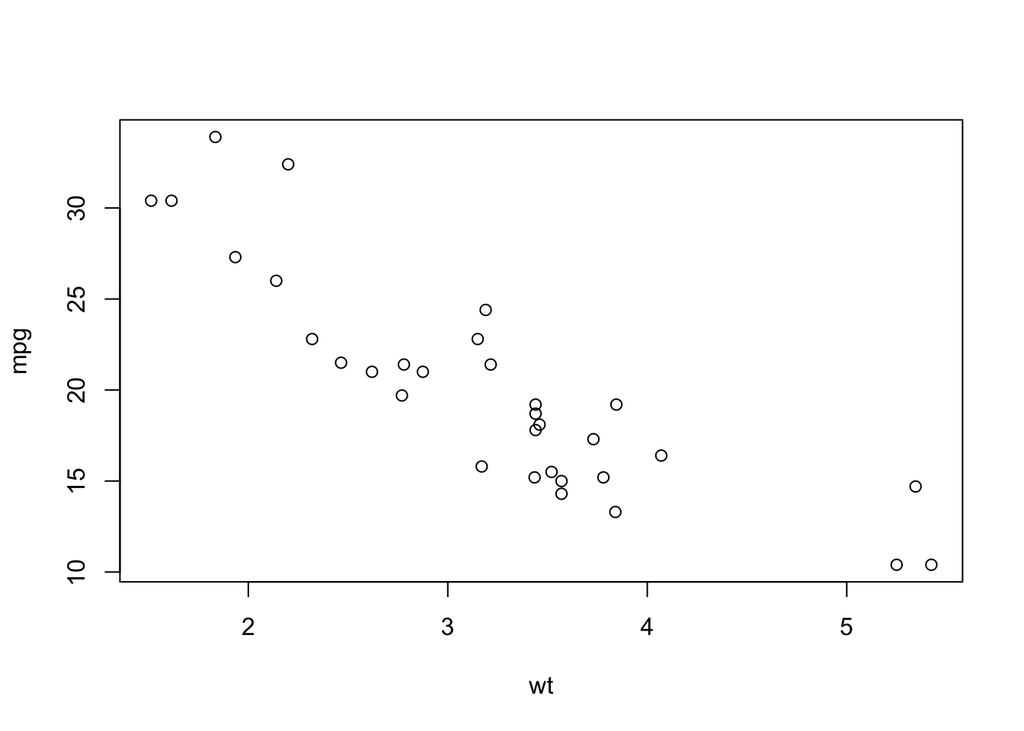

```r
plot(mpg ~ wt, mtcars)
```

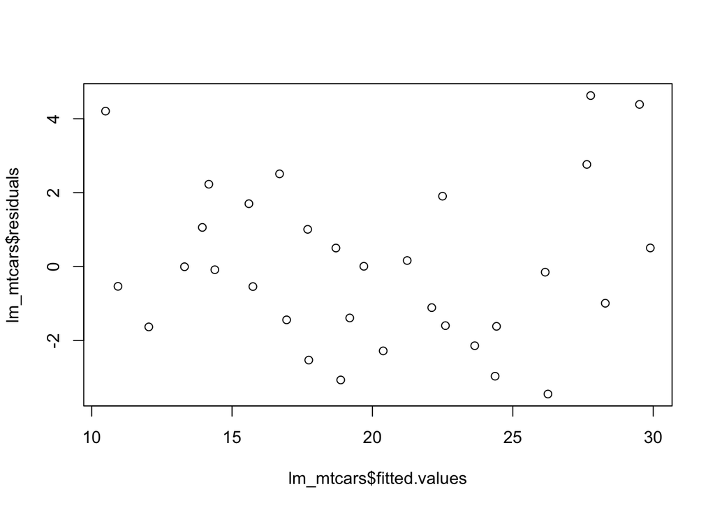

```r
# Build a linear model for the energy based on all other variables:
lm_mtcars <- lm(mpg ~ ., data = mtcars)

# Plot the residuals in function of your fitted observations
plot(lm_mtcars$fitted.values, lm_mtcars$residuals)
```

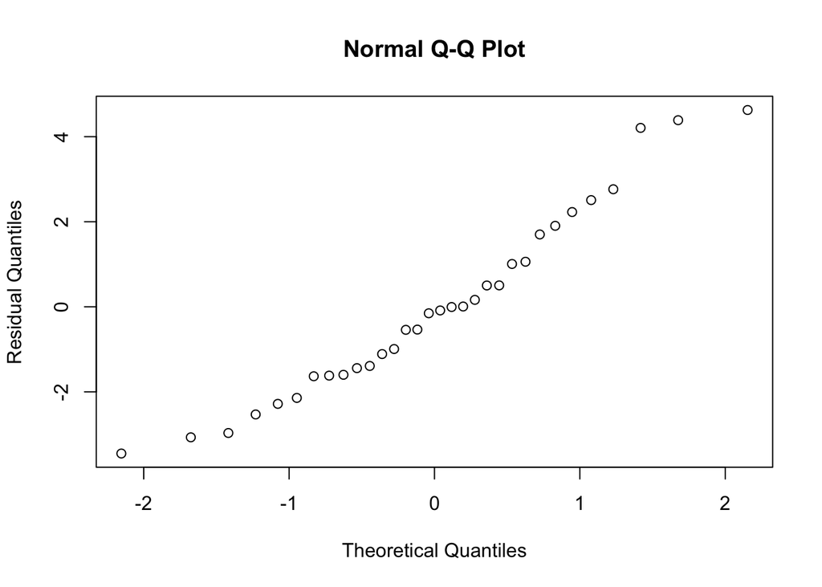

```r
# Make a Q-Q plot of your residual quantiles
qqnorm(lm_mtcars$residuals, ylab = "Residual Quantiles")
```

```r
# Summarize lm_choco
summary(lm_mtcars)
```

```
##
## Call:
## lm(formula = mpg ~ ., data = mtcars)
##
## Residuals:
##     Min      1Q  Median      3Q     Max
## -3.4506 -1.6044 -0.1196  1.2193  4.6271
##
## Coefficients:
##             Estimate Std. Error t value Pr(>|t|)
## (Intercept) 12.30337   18.71788   0.657   0.5181
## cyl         -0.11144    1.04502  -0.107   0.9161
## disp         0.01334    0.01786   0.747   0.4635
## hp          -0.02148    0.02177  -0.987   0.3350
## drat         0.78711    1.63537   0.481   0.6353
## wt          -3.71530    1.89441  -1.961   0.0633 .
## qsec         0.82104    0.73084   1.123   0.2739
## vs           0.31776    2.10451   0.151   0.8814
## am           2.52023    2.05665   1.225   0.2340
## gear         0.65541    1.49326   0.439   0.6652
## carb        -0.19942    0.82875  -0.241   0.8122
## ---
## Signif. codes:  0 '***' 0.001 '**' 0.01 '*' 0.05 '.' 0.1 ' ' 1
##
## Residual standard error: 2.65 on 21 degrees of freedom
## Multiple R-squared:  0.869,  Adjusted R-squared:  0.8066
## F-statistic: 13.93 on 10 and 21 DF,  p-value: 3.793e-07
```

### 2.7.3 Residuals & p-values

Often, the **assumptions of linear regression**, are stated as,

- **L**inearity: the response can be written as a linear combination of the predictors. (With noise about this true linear relationship.)
- **I**ndependence: the errors are independent.
- **N**ormality: the distribution of the errors should follow a normal distribution.
- **E**qual Variance: the error variance is the same at any set of predictor values.

If these assumptions are met, great! We can perform inference, **and it is valid**. If these assumptions are *not* met, we can still “perform” a $t$-test using `R`, but the results are **not valid**. The distributions of the parameter estimates will not be what we expect. Hypothesis tests will then accept or reject incorrectly. Essentially, **garbage in, garbage out.**

We’ll now look at a number of tools for checking the assumptions of a linear model.

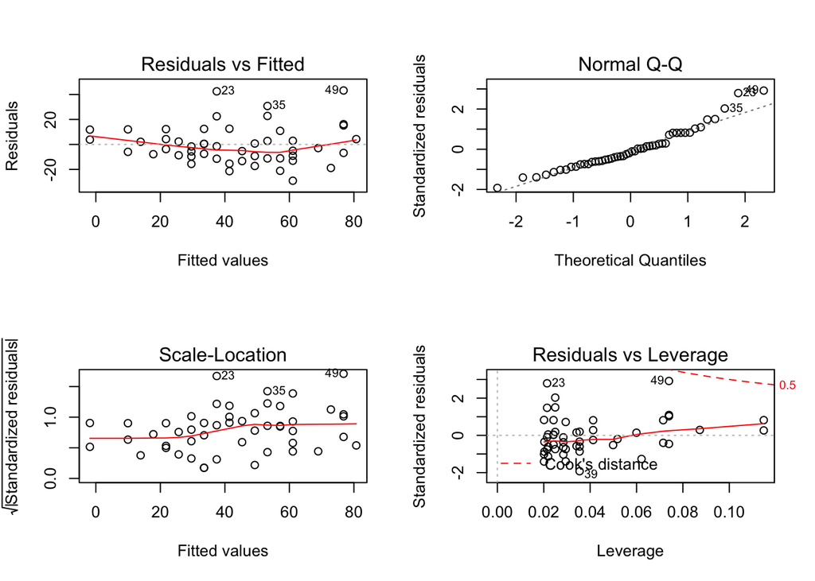

```r
data(cars) #Load cars data
fit = lm(dist ~ speed, cars) # Run a regression analysis
par(mfrow=c(2,2)) # Change the panel layout to 2 x 2
plot(fit)
```

```r
par(mfrow=c(1,1)) # Change back to 1 x 1
shapiro.test(resid(fit))
```

```
##
##  Shapiro-Wilk normality test
##
## data:  resid(fit)
## W = 0.94509, p-value = 0.02152
```

## 2.8 Clustering Deep Dive

Clustering machine learning technique is of the type unsupervised learning. In this scenarion, we will need to predict from the data as the predictors to either classify or quantify is not available. Many problemns in th ereal world do not have labels to help classify. A cluster is a colletion of data objects taht are similar to each other within a cluster and disimilar across the clusters. Clustering technique is often not measured as right or wrong, but as different data can provide different clusters.

### 2.8.1 k-means clustering

K-means clustering is the most commonly used unsupervised machine learning algorithm. We can use this technique to partition a given data set into a set of k groups (clusters), where k represents the number of groups specified apriori. The algorithm classifies objects in multiple groups (i.e., clusters), such that objects within the same cluster are as similar as possible (i.e., high intra-class similarity), whereas objects from different clusters are as dissimilar as possible (i.e., low inter-class similarity). In k-means clustering, each cluster is represented by its center (i.e, centroid) which corresponds to the mean of points assigned to the cluster.[Reference](https://uc-r.github.io/kmeans_clustering).

```r
# Load libraries
library(tidyverse)  # data manipulation
library(cluster)    # clustering algorithms
library(factoextra) # clustering algorithms & visualization

# Load dataset
df <- USArrests

# remove missing values
df <- na.omit(df)

# Scale the dataset to standardize
df <- scale(df)

# Apply k-means algorithm function for 2 clusters
k2 <- kmeans(seeds, centers = 2, nstart = 20)

# Print out k-means algorithm output
str(k2)
```

```
## List of 9
##  $ cluster     : int [1:210] 1 1 1 1 2 1 1 1 2 2 ...
##  $ centers     : num [1:2, 1:7] 12.804 17.975 13.639 15.967 0.862 ...
##   ..- attr(*, "dimnames")=List of 2
##   .. ..$ : chr [1:2] "1" "2"
##   .. ..$ : chr [1:7] "area" "perimeter" "compactness" "length" ...
##  $ totss       : num 2720
##  $ withinss    : num [1:2] 609 403
##  $ tot.withinss: num 1012
##  $ betweenss   : num 1708
##  $ size        : int [1:2] 127 83
##  $ iter        : int 1
##  $ ifault      : int 0
##  - attr(*, "class")= chr "kmeans"
```

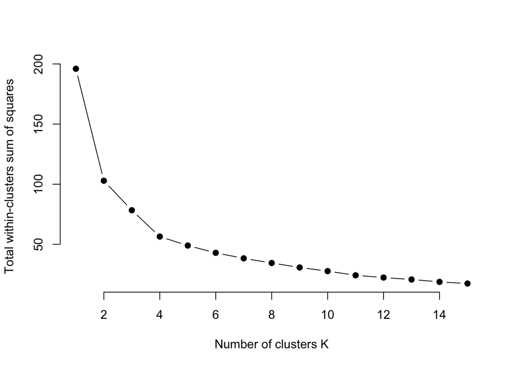

```r
# Elbow Method - To detrmine optimal clusters
# function to compute total within-cluster sum of square
wss <- function(k) {
  kmeans(df, k, nstart = 10 )$tot.withinss
}

# Compute and plot wss for k = 1 to k = 15
k.values <- 1:15

# extract wss for 2-15 clusters
wss_values <- map_dbl(k.values, wss)

plot(k.values, wss_values,
       type="b", pch = 19, frame = FALSE,
       xlab="Number of clusters K",
       ylab="Total within-clusters sum of squares")
```

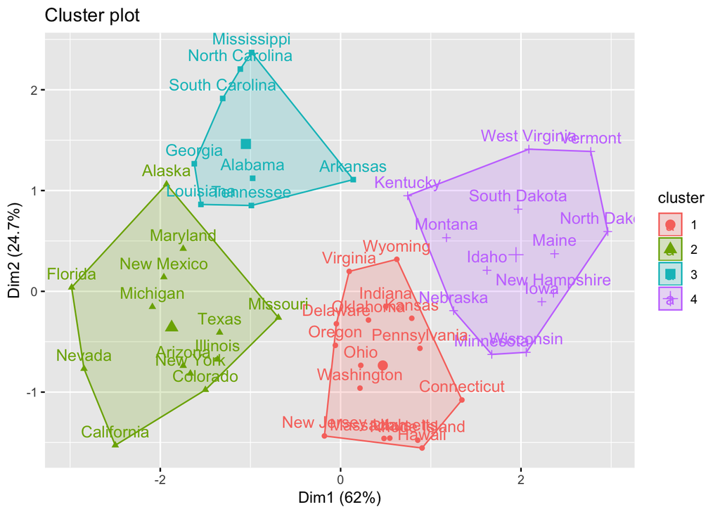

```r
# Cluster Visualization
final <- kmeans(df, 4, nstart = 25)
fviz_cluster(final, data = df)
```